# LabVenture

Normal visit breakdown

Author

carly s. lovas

# Exploring data of normal visits

| **Participating schools** |
| --- |
| Margaret Chase Smith Sch - Skowhegan |
| Hartford-Sumner Elementary School |
| Home School & Calais Elementary School |
| Noble Middle School |
| Se Do Mo Cha Middle School |
| Day Mountain Regional Middle School |
| Messalonskee Middle School |
| Mill Pond School |
| Philip W Sugg Middle School |
| Oak Hill Middle School |
| Home School & Walker Memorial School & Troy Central School |
| Gray-New Gloucester Middle School |
| Massabesic Middle School |
| Central Middle School |
| Mt Desert Elementary School & Tremont Consolidated School |
| Spruce Mountain Middle School |
| Home School & Day Mountain Regional Middle School |

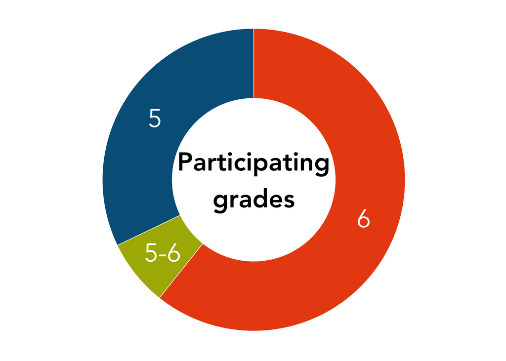

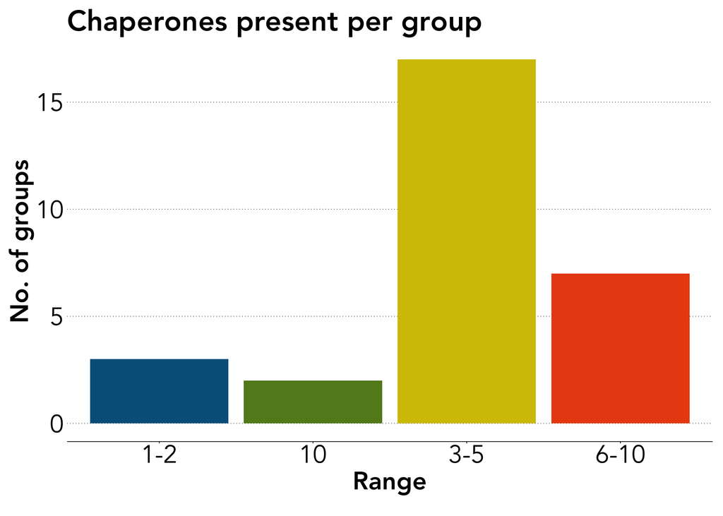

## Responses to verbal questions

How many students raised their hands in response to being asked questions by LabVenture educators?

#### Questions

- **Plankton**: What did you notice about plankton?
- **BSB**: Should we be concerned about black sea bass?
- **GoM**: What is happening to the Gulf of Maine?

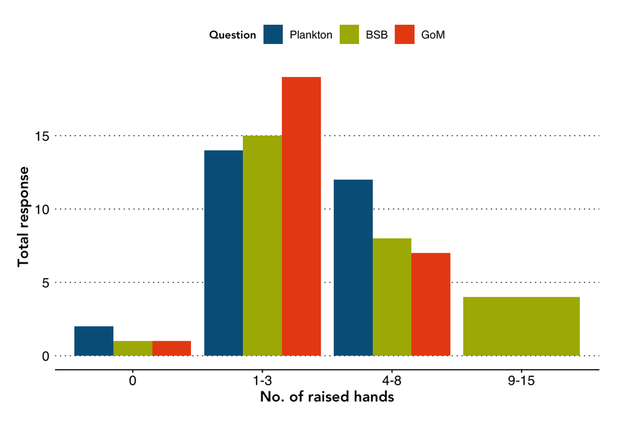

## Responses to clicker questions

What were students recalling as important information when asked *what is happening in the Gulf of Maine*?

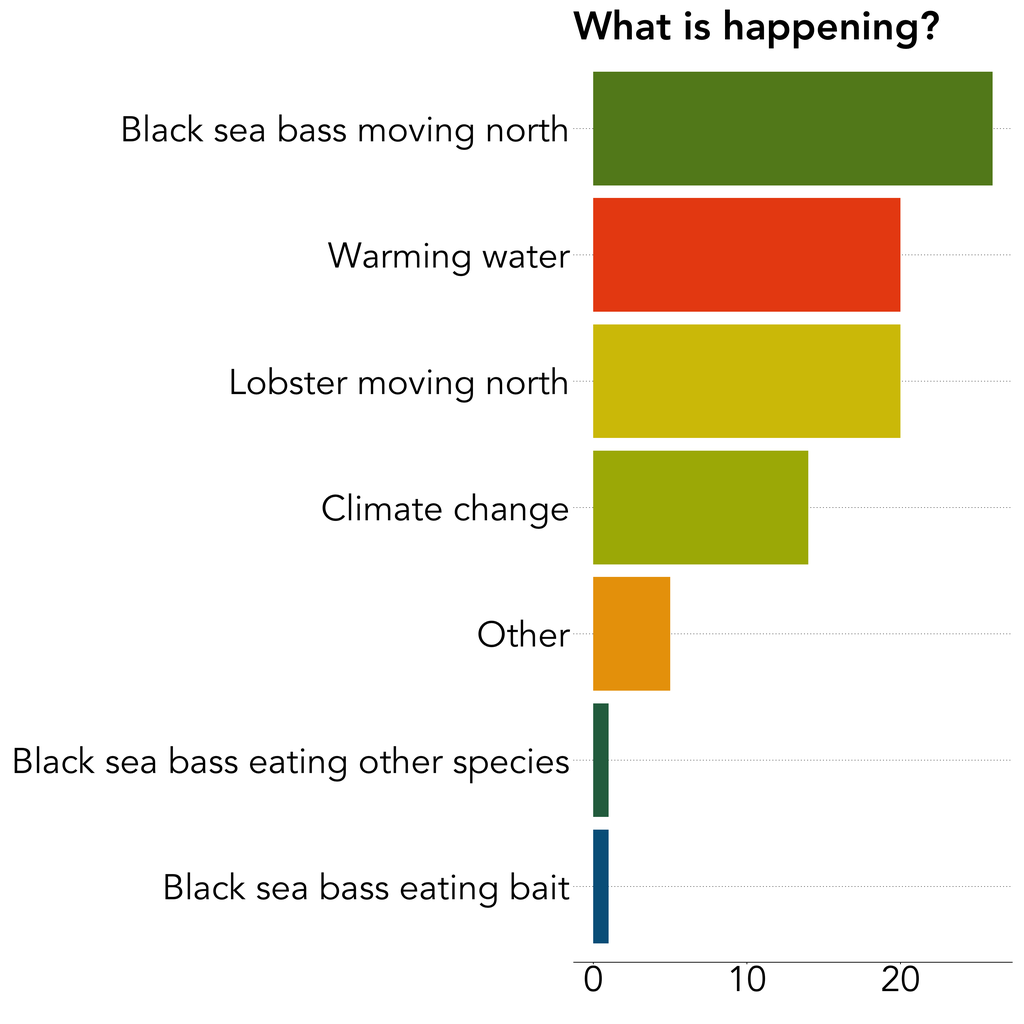

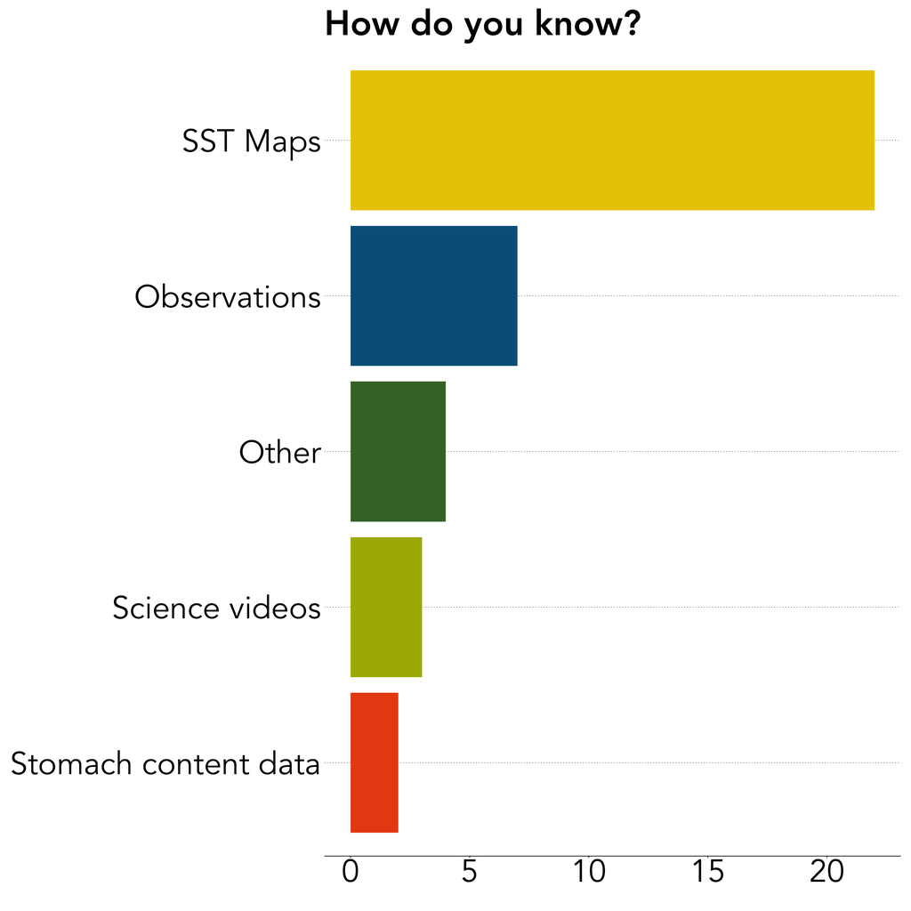

## Initial thoughts

Based on raw numbers, it seems that students are connecting the dots between warming in the Gulf of Maine and fisheries changes. The most frequent hand raising (ranging 1-8) appears to response to the question *what is happening in the Gulf of Maine*. **Species movement**, specifically Black sea bass, is the most referenced change in the Gulf of Maine, citing the **sea surface temperature** activity as how we know that this is happening. The next step is explore how demographics and program order impact response and engagement, as well as students ability to pick out important topics.